# Multiple Regression

STAT-471/571/701: Modern Data Mining

September 2017

## Introduction

Read:

- Chapter 3
- Note: Many important topics are in Appendices. Please go through them.

Objectives: 1. Introduction to multiple regression + Model specification + General linear models + LS estimates and their properties + Inference 2. Categorical predictors + Adding categorical predictors to the multiple regression (ANOVA) + Model with both continuous and categorical variables + Models with or without interactions 3. More about multiple Regression + Modeling non-linear relationships + Transformation of variables to meet linear model assumptions + Outliers, Leverage points 4. Summary 5. Appendices

### Case Study: Fuel Efficiency in Automobies

Goal of the study: How to build a fuel efficient car?

- Effects of features on a car
- Given a set of features, we’d like to estimate the mean fuel efficiency as well as the efficiency of one car
- Are Asian cars more efficient than cars built in other regions?

We will use the “car_04_regular.csv” data set to perform a Case Study on fuel efficiency in automobiles. Below is a quick description of all the features in our dataset.

| Feature | Description |
| --- | --- |
| Continent | Continent the Car Company is From |
| Horsepower | Horsepower of the Vehicle |
| Weight | Weight of the vehicle (thousand lb) |
| Length | Length of the Vehicle (inches) |
| Width | Width of the Vehicle (inches) |
| Seating | Number of Seats in the Vehicle |
| Cylinders | Number of Engine Cylinders |
| Displacement | Volume displaced by the cylinders, defined as $\pi/4 \times bore^{2} \times stroke \times \text{Number of Cylinders}$ |
| Transmission | Type of Transmission (manual, automatic, continuous) |

Specifically, fuel efficiency is measured by $Y$ = `MPG_City`

1. Effects of each feature on $Y$
2. Estimate
   - the mean `MPG_City` for all such cars specified below and
   - predict $Y$ for the particular car described below
3. Are cars built by Asian more efficient?

| Feature | Value |
| --- | --- |
| Continent | America |
| Horsepower | 225 |
| Weight | 4 |
| Length | 180 |
| Width | 80 |
| Seating | 5 |
| Cylinders | 4 |
| Displacement | 3.5 |
| Transmission | automatic |

#### Exploratory Data Analysis

It is always crucial to look at the data first. For the purpose of shortening the lecture time, we put this part in Appendix 1. There the original data “Car_04.csv” is cleaned and a new version called “car_04_regular.csv” is written out.

To summarize the EDA quickly, we excluded some high-performance cars with large Horsepower (HP > 400). We also take a subset of features, containing only the features described in the description table.

#### Read the data

Clear Work space, set working directory, and read in data

```r
# rm(list=ls()) # Remove all the existing variables
data1 <- read.csv("car_04_regular.csv", header=TRUE)
```

Quick exploration of data

```r
names(data1)
dim(data1)   # 226 cars and 13 variables
str(data1)
head(data1)
```

#### Define a car for prediction used later

```r
newcar <-  data1[1, ]  # Create a new row with same structure as in data1
newcar[1] <- "NA" # Assign features for the new car
newcar[2] <- "Am"
newcar["MPG_City"] <- "NA"
newcar["MPG_Hwy"] <- "NA"
newcar[5:11] <- c(225, 4, 180, 80, 5, 4, 3.5)
newcar$Make <-  "NA"
newcar[13] <- "automatic"
newcar
```

```
##   Make.Model Continent MPG_City MPG_Hwy Horsepower Weight Length Width
## 1         NA        Am       NA      NA        225      4    180    80
##   Seating Cylinders Displacement Make Transmission
## 1       5         4          3.5   NA    automatic
```

## Introduction to Multiple regression

### Model Specification

#### How does `Length` affect `MPG_City`?

It depends on how we model the response. We will investigate three models with `Length`.

For the ease of presentation, we define some predictors below that we will use in subsequent models:

$$x_1 = Length, \quad x_2 = Horsepower, \quad x_3 = Width, \quad x_4 = Seating, \quad x_5 = Cylinders, \quad x_6 = Displacement$$

We will create three models:

**M1. Our first model will only contain one predictor, Length:**

$$y_i = \beta_0 + \beta_1 \cdot x_{i1} + \epsilon$$
**Interpreation of $\beta_1$** is that in general, the mean $y$ will change by $\beta_1$ if a car is 1" longer. So we can’t really peel off the effect of the `Length` over $y$.

**M2. Next, we add the predictor `Horsepower` to our model**

$$y_i = \beta_0 + \beta_1 \cdot x_{i1} + \beta_2 \cdot x_{i2} + \epsilon$$

**Interpreation of $\beta_1$** is that in general, the mean $y$ will change by $\beta_1$ if a car is 1" longer and the ’HorsePower’s` are the same.

**M3. Finally, we fit a model with multiple predictors**

$$y_i = \beta_0 + \beta_1 x_{i1} + \beta_2x_{i2} + \beta_3x_{i3} + \beta_4x_{i4} + \beta_5x_{i5} + \beta_6x_{i6} + \epsilon$$

**Interpreation of $\beta_1$** is that in general, the mean $y$ will change by $\beta_1$ if a car is 1" longer and the rest of the features are the same.

**Question**: Are all the $\beta_1$s same in the 3 models above?

**No**. The effect of `Length` $\beta_1$ depends on the rest of the features in the model!!!!

### General linear models

In general, We define a multiple regression as

$$Y = \beta_0 + \beta_1 x_{i1} + \beta_2 x_{i2} + \dots + \beta_p x_{ip} + \epsilon_i$$

- Linearity Assumption for this model is

$$\textbf{E}(y_i | x_i) = \beta_0 + \beta_1 x_{i1} + \beta_2 x_{i2} + \dots + \beta_p x_{ip}$$

- The homoscedasticity assumption is

$$\textbf{Var}(y_i | x_{i1}, x_{i2}, \dots, x_{ip}) = \sigma^2$$

- The Error term is iid. and defined as

$$\epsilon_i \overset{iid}{\sim} \mathcal{N}(0, \sigma^2)$$

Parameters of interests are all the $\beta's$ and $\sigma^2$.

- Simple interpretations of each $\beta_i's$
- Simple models for predictions

### LS Estimates and their properties

These $\beta$ parameters are estimated using the same approach as simple regression, specifically by minimizing the sum of squared residuals ($RSS$):

$$\min_{\beta_0,\,\beta_1,\,\beta_{2},\dots,\beta_{p}} \sum_{i=1}^{n} (y_i - \beta_0 - \beta_1 x_{i1} - \beta_2 x_{i2} - \dots - \beta_p x_{ip})^{2}$$

To be specific:

We define let $X$ denote a $n × (p+1)$ matrix whose $(i,j)$th element is $x_{ij}$. That is:

$$X=
\begin{pmatrix}
1& x_{11} & x_{12} & \dots & x_{1p} \\
1& x_{21} & x_{22} & \dots & x_{1p} \\
\vdots & \vdots & \vdots & \ddots & \vdots \\
1& x_{n1} & x_{n2} & \dots & x_{np}
\end{pmatrix}$$

#### OLS Estimates:

$$\hat\beta = (X^{T}X)^{-1} \cdot X^{T}Y$$

The Variance of these Estimates

$$\textbf{VAR}[\hat\beta | X] = \sigma^{2} (X^{T}X)^{-1}$$

#### Residual Sum of Squares (RSS)

For multiple regression, $RSS$ is estimated as:

$$RSS = \sum_{i=1}^{n} \hat{\epsilon}_i^{2} = \sum_{i=1}^{n} (y_i - \hat\beta_0 - \hat\beta_1 x_{i1} - \hat\beta_2 x_{i2} - \dots - \hat\beta_p x_{ip})^{2}$$

#### Mean Sum of Squares (MSE), Residual Standard Error (RSE)

$\sigma^2$ is estimated by the Mean Sum of Squares (MSE). For multiple regression, MSE is defined as:

$$MSE = \frac{RSS}{n-p-1} \\
\text{where }p =\text{number of predictors used}$$

$\sigma$ is estimated by the Residual Standard Error (RSE). For multiple regression, RSE is defined as:

$$RSE = \sqrt{MSE} = \sqrt{\frac{RSS}{n-p-1}}$$

Let us compare the three model fits:

#### Model 1: Simple reg, MPG_City vs. Length

We first do a simple regression. Let the response $y_i$ be the `MPG_City` and the explanatory variable $x_{i1}$ be `Length` ($i = 1, \dots, n=226$).

$$y_i = \beta_0 + \beta_1 \cdot x_{i1} + \epsilon$$

Model assumptions:

1. Linearity: given `Length`, the mean of `MPG_City` is described as $\textbf{E}(y_i | x_i) = \beta_0 + \beta_1 x_i$
2. Equal variance: the variances of `MPG_City` are the same for any `Length` i.e. $\textbf{Var}(y_i | x_{i1}) = \sigma_{1}^2$
3. Normality: `MPG_City` is independent and normally distributed. i.e. $\epsilon_i \overset{iid}{\sim} \mathcal{N}(0, \sigma_{1}^2)$

We now create a model with `lm()`

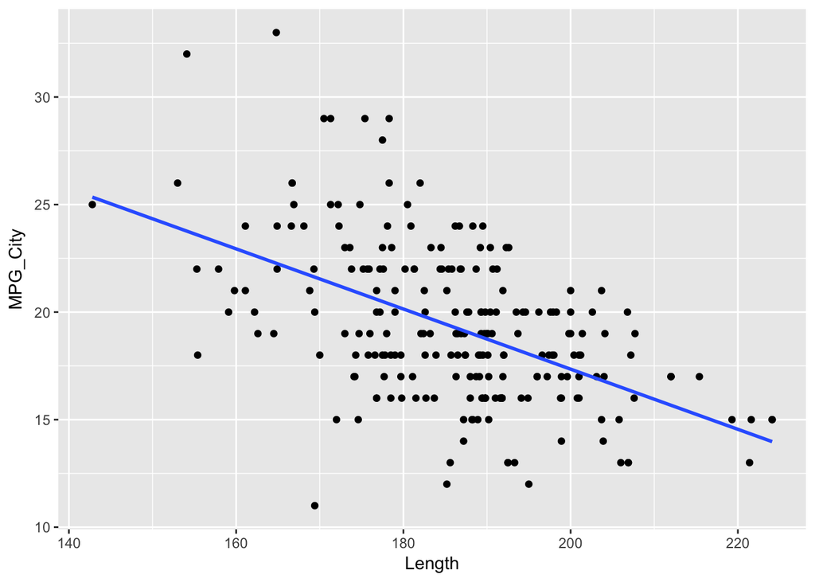

```r
fit1 <- lm(MPG_City ~ Length, data = data1)    # fit model 1

ggplot(data1, aes(x = Length , y = MPG_City)) +
  geom_point() +
  geom_smooth(method="lm",se=F)
```

Note from the summary below, the $\hat\beta$ for Length is estimated as -0.139833. We say on average MPG drops $.13983$ if a car is $1"$ longer.

```r
summary(fit1)
```

#### Model 2: Two features Length and Horsepower

Let the response $y_i$ be the `MPG_City` and the explanatory variables be `Length` and `Horsepower` ($i = 1, \dots, n=226$).

$$y_i = \beta_0 + \beta_1 \cdot x_{i1} + \beta_2 \cdot x_{i2} + \epsilon$$

```r
fit2 <- lm(MPG_City ~ Length + Horsepower, data = data1)
```

A couple quick notes:

1. The order for predictors plays no role.
2. The output of `lm()` is similar regardless how many predictors are used.
3. The model assumptions extended automatically here.

```r
summary(fit2)
```

**NOTICE**: Comparing fit2: `Length`+`Horsepower` to fit1: `Length`

The effects of variables ($\beta's$) are defined within the model. They all depend on what else are included or accounted for!

#### Model 3: Several continuous variables

We now add multiple variables to our model:

$$y_i = \beta_0 + \beta_1 x_{i1} + \beta_2x_{i2} + \beta_3x_{i3} + \beta_4x_{i4} + \beta_5x_{i5} + \beta_6x_{i6} + \epsilon$$

```r
fit3 <- lm(MPG_City ~ Length + Horsepower + Width + Seating +
           Cylinders + Displacement, data = data1)
```

```r
summary(fit3)
```

To summarize, the effects of `Length` from the above three models are

```r
data.frame(Model.1 = coef(fit1)[2], Model.2 = coef(fit2)[2], Model.3 = coef(fit3)[2])
```

```
##          Model.1     Model.2    Model.3
## Length -0.139833 -0.06191344 0.04909172
```

- They are different as expected
- Each one has its own meaning!

Based on the output from model 3:

1. $\hat\beta_{Length}$ = 0.0490917 for model 3. Is this estimate wrong?
2. Inference for each coefficient and for a set of coefficients.
   - What does each $t$-test do?
   - What does the $F$-test do here?
3. Is `Width` **THE** most important variable, `HP` the second, etc?
4. Can we conclude that none of the `Seating` or `Cylinders` is needed?

### Inference

Given a fixed model, assume all the linear model assumptions are correct we can make the following inferences:

1. For each $\beta$’s: t-intervals and t-tests
2. For a submodel: F-tests (will go through in some details)
3. Confidence intervals for the mean (similar to that in a simple regression)
4. Prediction intervals for an individual subject (similar to that in a simple regression)

#### t-tests

Keep model 3 and `fit3` as an example. What does each $t$-test do?

```r
summary(fit3)
```

```
##
## Call:
## lm(formula = MPG_City ~ Length + Horsepower + Width + Seating +
##     Cylinders + Displacement, data = data1)
##
## Residuals:
##     Min      1Q  Median      3Q     Max
## -4.8775 -1.4622  0.0727  1.1486  8.2608
##
## Coefficients:
##              Estimate Std. Error t value Pr(>|t|)
## (Intercept)  45.63372    4.02793  11.329  < 2e-16 ***
## Length        0.04909    0.01730   2.838  0.00497 **
## Horsepower   -0.02000    0.00408  -4.902 1.84e-06 ***
## Width        -0.35358    0.06878  -5.140 6.07e-07 ***
## Seating      -0.24135    0.14955  -1.614  0.10799
## Cylinders    -0.27169    0.23292  -1.166  0.24471
## Displacement -0.93813    0.37166  -2.524  0.01231 *
## ---
## Signif. codes:  0 '***' 0.001 '**' 0.01 '*' 0.05 '.' 0.1 ' ' 1
##
## Residual standard error: 2.036 on 219 degrees of freedom
## Multiple R-squared:  0.705,  Adjusted R-squared:  0.6969
## F-statistic: 87.22 on 6 and 219 DF,  p-value: < 2.2e-16
```

#### F-Tests

We continue to derive a F-test to test a set of $\beta's$ being 0.

We now look at the hypothesis that:

$$H_0: \beta_\text{Seating}=\beta_\text{Cylinder}=0$$

To be more specific, the $H_0$ is

**Reduced model:**

$$y_i = \beta_0 + \beta_{\text{Length}} x_{\text{i,Length}} + \beta_{\text{HP}}x_{\text{i,HP}} + \beta_{\text{Width}}x_{\text{i, Width}} + \beta_{\text{Displacement}}x_{\text{i, Displacement}} + \epsilon_i$$

and the $H_1$ is

**Full model:**

$$y_i = \beta_0 + \beta_{\text{Length}} x_{\text{i,Length}} + \beta_{\text{HP}}x_{\text{i,HP}} + \beta_{\text{Width}}x_{\text{i, Width}} + \\
\beta_{\text{Seating}}x_{\text{i, Seating}} + \beta_{\text{Cylinders}}x_{\text{i, Cylinders}} + \beta_{\text{Displacement}}x_{\text{i, Displacement}} + \epsilon_i$$

**Theorem**: Assume the linear model assumptions hold, then under the $H_0$

$$F_{\text{stat}}:=\frac{\frac{RSS(H_0)-RSS(H_1)}{df_1}}{\frac{RSS(H_1)}{df_2}} \sim F_{df_1, df_2} \\
\text{where} \quad {df}_1= \text{# of parameters in } H_1 - \text{# of parameters in } H_0 \\
\quad {df}_2= \text{# of observations} - \text{# of parameters in } H_1$$

##### Use `anava()` to carry out the F-test

We now look at the hypothesis that:

$$H_0: \beta_{Seating}=\beta_{Cylinder}=0$$

To explore, we can run a model without `Seating` and `Cylinder`.

```r
fit3.0 <- lm(MPG_City ~ Horsepower + Length + Width + Displacement, data = data1) # under H0
sum((summary(fit3.0)$residuals)^2) # RSS(H_0)
sum((summary(fit3)$residuals)^2) # RSS(H_1)
```

$$F_{\text{stat}}=\frac{\frac{RSS(H_0)-RSS(H_1)}{df_1}}{\frac{RSS(H_1)}{df_2}} = \frac{\frac{923.82 - 907.76}{2}}{\frac{907.76}{219}}=1.9373.$$

Based on the $F$-test given above, the $p$-value is
$$P(F_{2,219} > 1.9373)$$

```r
pf(1.9373, 2, 219, lower.tail=F)
```

$F$-test can be done by `anova(H_0, H_1)`.

```r
fit3.0 <- lm(MPG_City ~ Horsepower + Length + Width + Displacement, data = data1)
anova(fit3.0, fit3)
```

```
## Analysis of Variance Table
##
## Model 1: MPG_City ~ Horsepower + Length + Width + Displacement
## Model 2: MPG_City ~ Length + Horsepower + Width + Seating + Cylinders +
##     Displacement
##   Res.Df    RSS Df Sum of Sq      F Pr(>F)
## 1    221 923.82
## 2    219 907.76  2     16.06 1.9373 0.1466
```

**Conclusion:** The p-value being .1466 gives us no evidence to reject the null hypothesis.

Questions based on the summary for `fit3`

1. What is the $F$ statistics from `summary(fit3)`?
2. Can you perform a $F$-test for each $\beta$ being 0? What is the relationship between the F-test and the t-test?

#### Confidence Interval for the Mean

Base on Model 3, the mean of `MPG_City` among all cars of length=180, HP=225, width=80, seating=5, cylinders=4, displacement=3.5, transmission=“automatic”, continent=“Am” is

We will get the prediction, standard error and the confident intervals by `predict()`.

```r
predict(fit3, newcar, interval = "confidence", se.fit = TRUE)
```

```
## $fit
##        fit      lwr      upr
## 1 16.10679 14.56184 17.65175
##
## $se.fit
## [1] 0.7839001
##
## $df
## [1] 219
##
## $residual.scale
## [1] 2.035936
```

#### Prediction Interval

Base on Model 3, `MPG_City` for this new design is

The prediction interval can be obtained by `predict()`.

```r
predict(fit3, newcar,  interval = "predict", se.fit = TRUE) # future prediction intervals
```

#### Model Diagnoses

To check the model assumptions are met, we examine the residual plot and the qqplot of the residuals.

We use the first and second plots of `plot(fit)`.

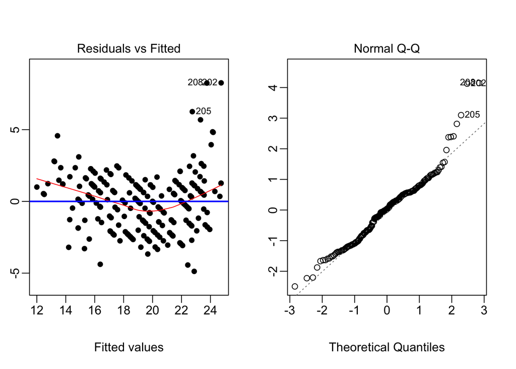

```r
par(mfrow=c(1,2), mar=c(5,2,4,2), mgp=c(3,0.5,0))
plot(fit3, 1, pch=16) # residual plot
abline(h=0, col="blue", lwd=2)
plot(fit3, 2) # qqplot
```

Roughly speaking, the linearity, homoscedasticity and normality assumptions are satisfied.

## Categorical Predictors

Let’s use `Continent` as one variable. It has three categories. We explore the following questions:

1. Are Asian cars more efficient?
2. How does `Continent` affect the `MPG`?

```r
attach(data1)
levels(Continent)
```

Model with a categorical variable is same as a “One Way ANOVA”

First, we get the sample means and sample standard error for each group, and plot each

```r
data1 %>%
group_by(Continent) %>%
  summarise(
    mean = mean(MPG_City),
    sd  = sd(MPG_City)
  )
```

```
## # A tibble: 3 x 3
##   Continent     mean       sd
##      <fctr>    <dbl>    <dbl>
## 1        Am 18.72973 2.985340
## 2        As 20.24490 4.196369
## 3         E 18.25926 3.216615
```

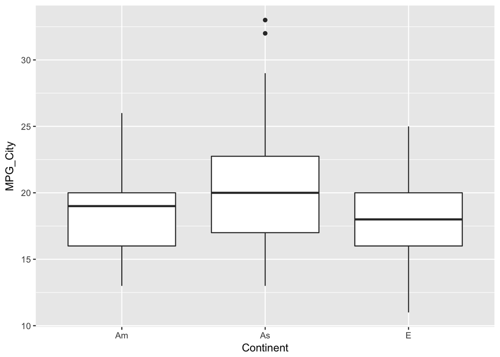

```r
ggplot(data1) + geom_boxplot(aes(x = Continent, y = MPG_City))
```

We use indicator predictors to analyze the effect of `Continent`.

### Model 1 - One Way ANOVA

$$y_{i|x=Am} = \mu_{Am} + \epsilon_i$$
$$y_{i|x=As} = \mu_{As} + \epsilon_i$$
$$y_{i|x=E} = \mu_{E} + \epsilon_i$$
where $\mu_{Am}$, $\mu_{As}$ and $\mu_{E}$ are the mean MPG of each continent, and $\epsilon \sim \mathcal{N}(0,\sigma^2)$. We want to compare the three means and this can be done through linear model with indicator functions.

Let

- `Am` as the base
- $x_1$ be the indicator function of being `As` $I(Continent = As)$
- $x_2$ be the indicator function of being `E` $I(Continent = E)$
- $\beta_{Am} = \textbf{E}(MPG|Am)$
- $\beta_{As} = \textbf{E}(MPG|As)-\textbf{E}(MPG|Am)$: the increment between Asia and America
- $\beta_E = \textbf{E}(MPG|E)-\textbf{E}(MPG|Am)$: the increment between Europe and America

Then the above Anova model is same as

$$y_i = \beta_{Am} + \beta_{As} x_{1,i} + \beta_E x_{2,i} + \epsilon_i = \beta_{Am} + \beta_{As} I(Continent = As) + \beta_E I(Continent = E) + \epsilon_i$$
Now we use `lm()` to fit the model.

```r
fit.continent = lm(MPG_City ~ Continent, data1)
summary(fit.continent)
```

```
##
## Call:
## lm(formula = MPG_City ~ Continent, data = data1)
##
## Residuals:
##     Min      1Q  Median      3Q     Max
## -7.2593 -2.7297 -0.2449  1.7551 12.7551
##
## Coefficients:
##             Estimate Std. Error t value Pr(>|t|)
## (Intercept)  18.7297     0.4197  44.624  < 2e-16 ***
## ContinentAs   1.5152     0.5560   2.725  0.00694 **
## ContinentE   -0.4705     0.6462  -0.728  0.46734
## ---
## Signif. codes:  0 '***' 0.001 '**' 0.01 '*' 0.05 '.' 0.1 ' ' 1
##
## Residual standard error: 3.611 on 223 degrees of freedom
## Multiple R-squared:  0.05522,    Adjusted R-squared:  0.04674
## F-statistic: 6.517 on 2 and 223 DF,  p-value: 0.001776
```

The $F_{test}$ here is to test $H_0: \; \beta_{As} = \beta_{E} = 0$, i.e., there is no difference among the three regions. We reject $H_0$ at $\alpha=0.01$.

We can also see the coding from here that Am is the base, each coefficient captures the effect of the level vs. Am.

```r
model.matrix(fit.continent)[5:8, ]
```

To estimate the mean difference between two regions, we can use the package `contrast()`

```r
contrast(fit.continent, list(Continent = 'As'), list(Continent = 'Am'))
contrast(fit.continent, list(Continent = 'As'), list(Continent = 'E'))
```

We can choose the base level as we want. We demonstrate this by setting up Asian cars as the base category:

```r
data1$Continent <- factor(data1$Continent, levels = c("As", "Am", "E"))
summary(lm(MPG_City ~ Continent, data1))
```

Note that:

1. The $F_{test}$ should be the same.
2. The coefficients are different but the mean estimates are the same.

```r
data1$Continent <- factor(data1$Continent, levels = c("Am", "As", "E"))
```

Remarks: `fit.continent` can also be obtained from

```r
fit.continent.1 <- lm(MPG_City ~ I(Continent == "As") + I(Continent == "E") , data1)
summary(fit.continent)
model.matrix(fit.continent.1)[1:10, ]
```

We also show a model without intercept $\beta_0$

```r
fit.continent.2 <- lm(MPG_City ~ 0 + Continent , data1) #
summary(fit.continent.2)
model.matrix(fit.continent.2)[1:10, ]
```

Drawback of one way Anova: other factors should be also taken into consideration.

### Model 2 - Model with Interaction

Let’s take a look at the model which only includes `HP` and `Continent`.

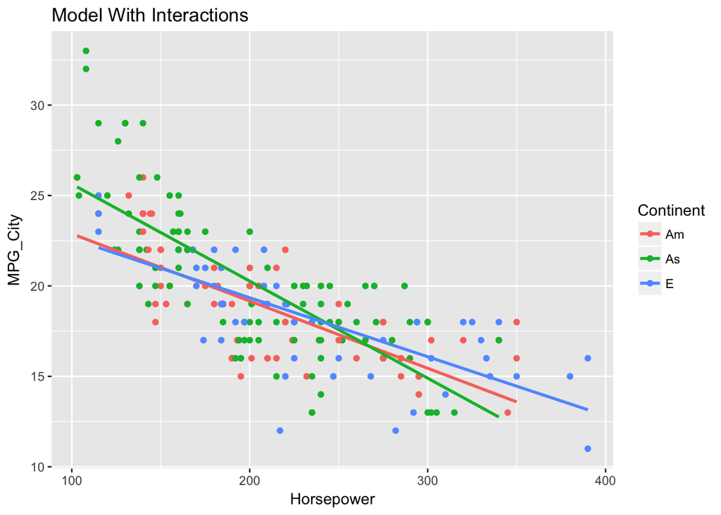

```r
ggplot(data1, aes(x = Horsepower, y = MPG_City, color = Continent)) +
  geom_point() +
  geom_smooth(method = "lm" , se =F) +
  labs(title = "Model With Interactions")
```

As we can see from the plot, Asian cars with smaller HP are more effiecient; while European cars with larger HP are more efficient. So we introduce models with interactions.

Model with interactions: fit $y$ vs $Horsepower$ by $Continent$.

$$y_{i|Am,\, HP} = \beta_{Am} + \beta_{1_{Am}} \cdot HP + \epsilon_i$$
$$y_{i|As,\, HP} = \beta_{As} + \beta_{1_{As}} \cdot HP + \epsilon_i$$

$$y_{i|E,\, HP} = \beta_{E} + \beta_{1_{E}} \cdot HP + \epsilon_i$$

This can be done through as follows:

$$MPG= \beta_{Am} + \beta_{As} \cdot I(Continent = As) + \beta_E \cdot I(Continent = E) + \\
\beta_{1_{Am}} \cdot HP + \beta_{1_{As}} \cdot HP \cdot I(Continent = As) + \beta_{1_E} \cdot HP \cdot I(Continent = E) + \epsilon$$

Similarly,

- $\beta_{As}$ is the increment of intercept between Asian and American, …
- $\beta_{1_{As}}$ is the increment of slope between Asian and American, …

Use `lm()` with interaction:

```r
fit.with.interaction <- lm(MPG_City ~ Horsepower*Continent, data1)
summary(fit.with.interaction)
```

Question: is the interaction really there? are the effects of HP the same across `Continent`?

### Model 3 - Model without Interaction

We first plot our models without interactions.

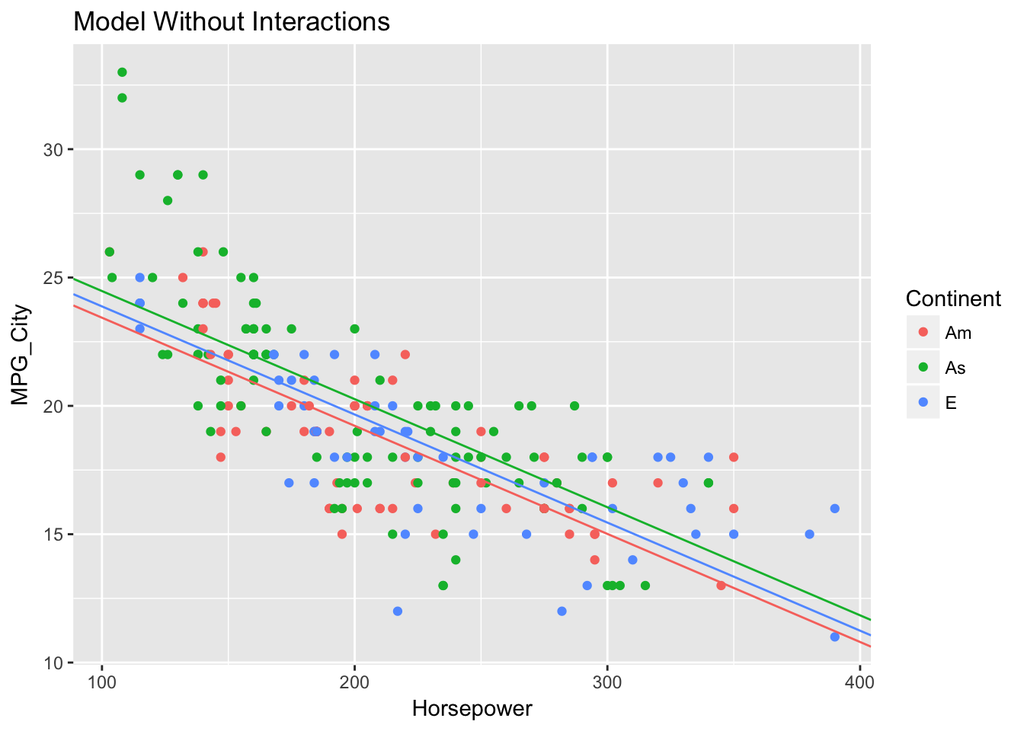

```r
fit.no.interation <- lm(MPG_City ~ Continent+Horsepower, data1)
coefs <- (summary(fit.no.interation))$coefficients[, 1]

ggplot(data1, aes(x = Horsepower, y = MPG_City, color = Continent)) +
  geom_point() +
  geom_abline(intercept =coefs[1], slope=coefs[4], color ="#F8766D") +
  geom_abline(intercept =coefs[1]+coefs[2], slope=coefs[4], color = "#00BA38") +
  geom_abline(intercept =coefs[1]+coefs[3], slope=coefs[4], color ="#619CFF") +
  labs(title = "Model Without Interactions")
```

For a model without interaction, we assume that the effect of `HP` on `MPG_{City}` is the same regardless of which region the cars are produced.

$$MPG= \beta_{Am} + \beta_{As} \cdot I(Continent = As) + \beta_E \cdot I(Continent = E) + \beta_1 \cdot HP + \epsilon$$

```r
fit.no.interation <- lm(MPG_City ~ Horsepower + Continent, data1)
summary(fit.no.interation)
```

```
##
## Call:
## lm(formula = MPG_City ~ Horsepower + Continent, data = data1)
##
## Residuals:
##     Min      1Q  Median      3Q     Max
## -6.9479 -1.4863  0.0533  1.4760  8.8633
##
## Coefficients:
##              Estimate Std. Error t value Pr(>|t|)
## (Intercept) 27.646162   0.622899  44.383   <2e-16 ***
## Horsepower  -0.042115   0.002615 -16.108   <2e-16 ***
## ContinentAs  1.038929   0.379580   2.737   0.0067 **
## ContinentE   0.440715   0.443406   0.994   0.3213
## ---
## Signif. codes:  0 '***' 0.001 '**' 0.01 '*' 0.05 '.' 0.1 ' ' 1
##
## Residual standard error: 2.457 on 222 degrees of freedom
## Multiple R-squared:  0.5644, Adjusted R-squared:  0.5585
## F-statistic: 95.87 on 3 and 222 DF,  p-value: < 2.2e-16
```

To test there is no interaction is same as to test
$$H_0: \beta_{1_{AS}} = \beta_{1_E} = 0$$
which we can do with `anova()`

```r
anova(fit.no.interation, fit.with.interaction)
```

To test whether `Continent` is significant in this model, we can use `anova(H_0, H_1)`. Alternativaly, we can use `Anova()` from the car package.

```r
Anova(fit.no.interation)
```

We fail to reject $H_0$ at $\alpha=0.01$, i.e., controlling HP, we do not have the evidence to say the effect of `Continent` is different.

## More about Multiple Regression

We now try a model which includes all variables (sensible ones!!!!!)

```r
names.exclude <- names(data1) %in% c("Make.Model", "MPG_Hwy", "Make")
# names.exclude <- c("Make.Model", "MPG_Hwy", "Make") # doesn't work.
data2 <- data1[!names.exclude]  # Take a subset with all var's but "Make.Model","MPG_Hwy","Make"
names(data2)
```

Or use `dplyr`!!!!!!

```r
data2 <- select(data1, -Make.Model, -MPG_Hwy, -Make)  #how convenient!!!
names(data2)
```

```
##  [1] "Continent"    "MPG_City"     "Horsepower"   "Weight"
##  [5] "Length"       "Width"        "Seating"      "Cylinders"
##  [9] "Displacement" "Transmission"
```

**QUESTION**: What would have happened if you have added Make.Model into the model???

```r
fit.all <- lm(MPG_City ~., data2)
```

```r
summary(fit.all)
```

The $t$-table is pretty messy, many variables are not significant, need to do `Anova()`

```r
Anova(fit.all)
```

Comments:

1. `Continent` is not needed after accounting for all other variables. That says we don’t have evidence to show that one continent tends to produce more efficient cars than the others.
2. Can we drop all the variables with $p$-values larger than $.05$???????
3. Take a look at `Transmission`. There are predominately automatic cars. Perhaps we should only include automatic cars and change our population.

```r
table(data2$Transmission)
```

4. We don’t have to use a model with all $p$-valueless being small!

**Model diagnostic**: check if three assumptions of linear models are met.

Residuals vs Fitted and qqnormal Plot, both plots look fine.

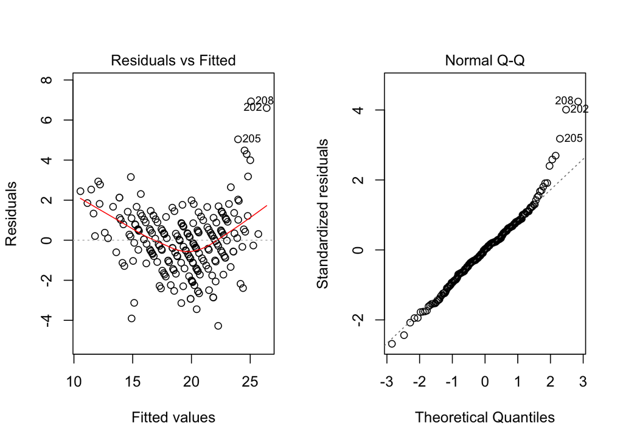

```r
par(mfrow=c(1,2))
plot(fit.all, 1)
plot(fit.all, 2)
```

We now do a Confidence Interval for the mean of cars like our `newcar`

```r
fit.mean.new <- predict(fit.all, newcar, interval = "confidence")
fit.mean.new
```

We also do a prediction interval on this `newcar`

```r
fit.new <- predict(fit.all, newcar, interval = "prediction", se.fit=TRUE)
fit.new$fit
fit.new$se.fit
fit.new$residual.scale
```

## Summary

Summary about linear models:

1. linear model is simple and has nice interpretation
2. Coefficient for each predictor depends on the model
3. LS automatically adjusts the unit of predictors
4. $t$-tests: the effect of each coeff. (Does not rank the importance of the predictors)
5. $F$-tests: test a set of predictors (t-tests being special cases!)
6. Model assumptions: all in residuals

### BIGGEST QUESTION: How to identify a set of important variables or Which model to use?????

Choose models with small “prediction errors”!!!! Next Lecture..

## Appendices

### Appendix 1: Clean dataset Cars_04 > car_04_relular.csv

```r
# Caution: you need to have Cars_04.csv in order to run this chunk!!!!!
data = read.csv("Cars_04.csv", header=T, as.is=F)
str(data)   # There are 242 cars in the data
data.comp <- na.omit(data)  # It deletes any car with a missing value - not a good idea.
str(data.comp)  #182 cars with complete records for all the variables.

### Explore the data
names(data)
head(data)
summary(data)

par(mgp=c(1.8,.5,0), mar=c(3,3,2,1))
hist(data$Horsepower, breaks=20, col="blue")  # notice that there are some super powerful cars

### Let's find out which are the super powerful cars
data$Make.Model[data$Horsepower > 400] # Show models with Horsepower > 400
data$Make.Model[data$Horsepower > 390]
data$Make.Model[data$Horsepower <= 100]

### We could find cars with horsepower > 400
data[data$Horsepower > 400, "Make.Model"]

### Let's concentrate on  "regular" cars and exclude those super expensive ones
datacar <- data[(data$Horsepower <=390) & (data$Horsepower > 100), ]

### Take a subset with relevant variables
variables <-  c("Make.Model", "Continent", "MPG_City", "MPG_Hwy",
              "Horsepower","Weight","Length", "Width",
              "Seating","Cylinders","Displacement",
              "Make", "Transmission")

data1 <- datacar[, variables]  # subset
str(data1)
write.csv(data1, file="car_04_regular.csv", row.names = FALSE)
                            # Output the data and name it car_04_regular.csv
```

### Appendix 2: Using formulae to obtain LS estimates

Take `fit3` and recreate $\hat\beta$’s.

```r
design.x <-  model.matrix(fit3)  #fit3$model gives us Y and x1 x2...xp
y <- fit3$model[, 1]
design.x[, 1]
rse <- (summary(fit3))$sigma
beta <-  (solve( t(design.x) %*% design.x)) %*% t(design.x) %*% y # reconstruct LS estimates
beta
```

Reconstructing the Co variance matrix from `fit3`

```r
summary(fit3)$cov.unscaled   # inverse (X' X)
cov.beta <- (rse^2) * (summary(fit3)$cov.unscaled)  # alternatively we can get the cov matrix this way
```

Calculating the Standard Error from `fit3`

```r
sd.beta <- sqrt(diag(cov.beta)) # check to see this agrees with the sd for each betahat
sd.beta  # this shoulbe be same as the Std. Error in the summary table

summary(fit3)$coeff[, "Std. Error" ]
```

### Appendix 3: Nonlinearity in predictors: transformations

The $x$ variable may relate to $y$ through a function of $x$, say $log(x)$ or $x^{2}$.

- We can handle this by transforming $x$.
- First let’s find out if there is some non-linear relationship there by looking at pairwise scatter plots

Based on the following `Horsepower` may need a transformation

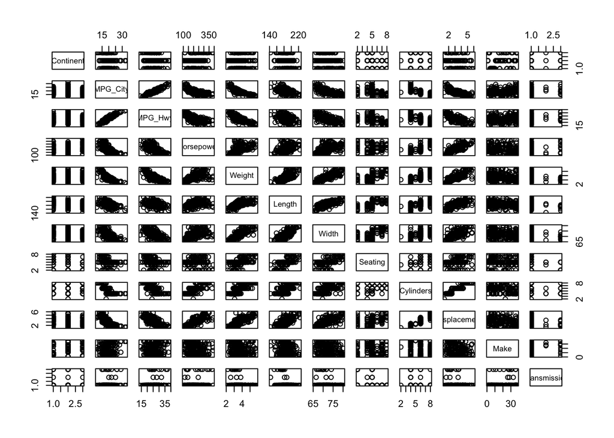

```r
pairs(data1[, -1])
```

We look at `Horsepower` vs. $\frac{1}{Horsepower}$

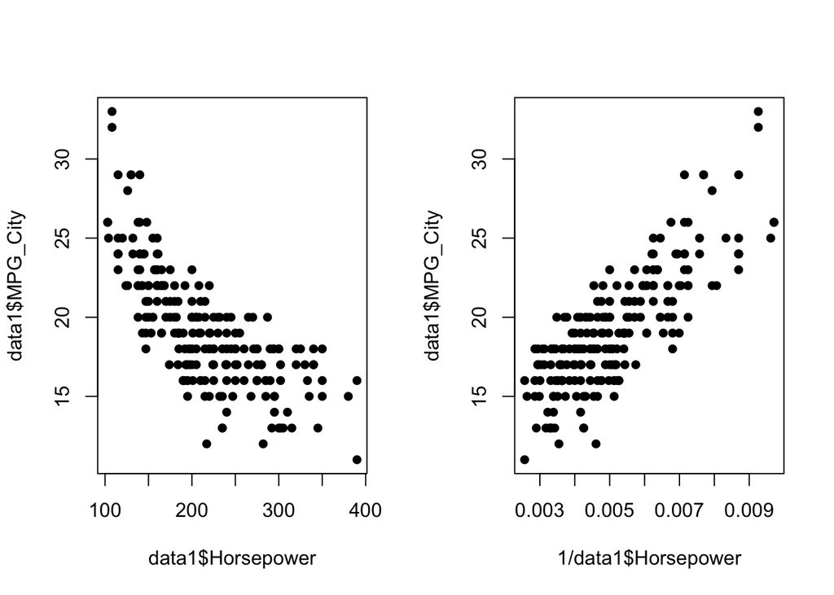

```r
par(mfrow=c(1,2))
plot(data1$Horsepower, data1$MPG_City, pch=16)
plot(1/data1$Horsepower, data1$MPG_City, pch=16)  #looks better!
```

$\frac{1}{Horsepower}$ Looks good, so we make a model using that.

```r
fit.transform <- lm(MPG_City~ I(1/Horsepower), data1)  # Use I()
plot(fit.transform, 1)
```

We also try to fit $Horsepower^{2}$

```r
fit12 <- lm(MPG_City ~ Horsepower + I(Horsepower^2), data1) # fit a quadratic function
summary(fit12)
plot(fit12$fitted, fit12$residuals, pch=16)
abline(h=0, lwd=4, col="red")
plot(fit12, 2)
```

### Appendix 4: Model Diagnoses via a perfect linear model scenario

We look to fit a model containing 100 points of the equation

```r
par(mfrow=c(1,1))

x <- runif(100)
y <- 1+2*x+rnorm(100,0, 2)
fit <- lm(y~x)
fit.perfect <- summary(lm(y~x))
rsquared <- round(fit.perfect$r.squared,2)
hat_beta_0 <- round(fit.perfect$coefficients[1], 2)
hat_beta_1 <- round(fit.perfect$coefficients[2], 2)
plot(x, y, pch=16,
     ylim=c(-8,8),
     xlab="a perfect linear model: true mean: y=1+2x in blue, LS in red",
     main=paste("R squared= ",rsquared,
                ", LS estimates b1=",hat_beta_1, "and b0=", hat_beta_0))
abline(fit, lwd=4, col="red")
lines(x, 1+2*x, lwd=4, col="blue")
```

Residual plot

```r
plot(fit$fitted, fit$residuals, pch=16,
     ylim=c(-8, 8),
     main="residual plot")
abline(h=0, lwd=4, col="red")
```

Check normality

```r
qqnorm(fit$residuals, ylim=c(-8, 8))
qqline(fit$residuals, lwd=4, col="blue")
```

The following example tells us we can’t look at y directly to check the normality assumption. Why not? We really need to examine residuals!

```r
par(mfrow=c(2,2))
x <- runif(1000)
y <- 1+20*x+rnorm(1000,0, 2)
plot(x, y, pch=16)
hist(y, breaks=40)
qqnorm(y, main="qqnorm for y")
qqline(y)
fit <- lm(y~x)
qqnorm(fit$residuals, main="qqnorm for residuals")
qqline(fit$residuals)
par(mfrow=c(1,1))

data.frame( mean = mean(y), std.dev = sd(y))
```

### Appendix 5: Colinearity

When some $x$’s are highly correlated we can’t separate the effect. But it is still fine for the purpose of prediction.

A simulation to illustrate some consequences of colinearity. Each $p$-value for $x_1$ and $x_2$ is large but the null of both $\beta's = 0$ are rejected…. Because $x_1$ and $x_2$ are highly correlated.

```r
par(mfrow=c(2,1))
x1 <- runif(100)
x2 <- 2*x1+rnorm(100, 0,.1)    # x1 and x2 are highly correlated
y <- 1+2*x1+rnorm(100,0, .7)   # model
newdata.cor <- cbind(y, x1,x2) # to see the strong correlations..
pairs(newdata.cor, pch=16)
```

$x_1$ is a useful predictor

```r
summary(lm(y~x1))
```

$x_2$ is a useful predictor

```r
summary(lm(y~x2))
```

$x_1$ and $x_2$ together show that one is not

```r
summary(lm(y~x1+x2))
```

Putting both highly correlated var’s together we can’t separate the effect of each one, though the model is still useful!

```r
data.frame(Corealation = cor(x1, x2))
```

### Appendix 6: F distribution

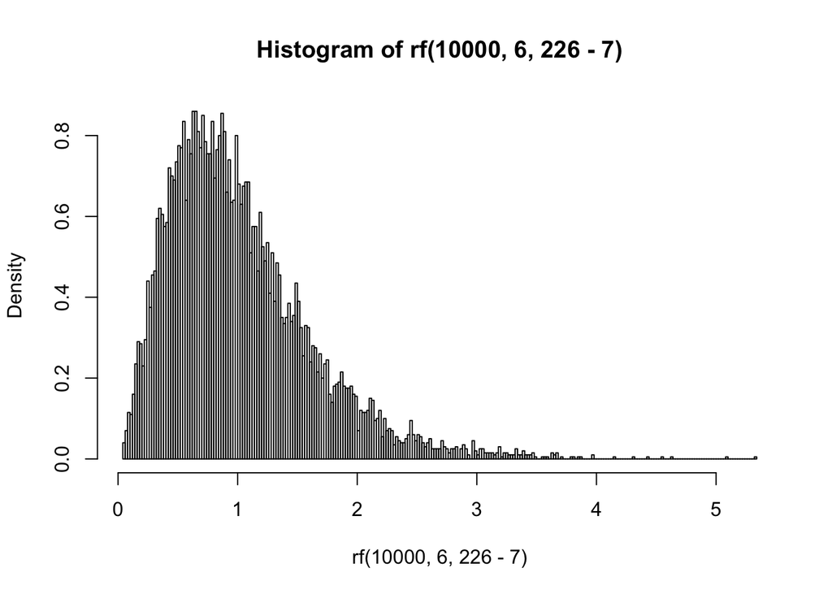

```r
###
hist(rf(10000, 6, 226-7), freq=FALSE, breaks=200)   # pretty skewed to the right
```

```r
Fstat=(summary(fit3))$fstat    # The Fstat, df1, df2
pvalue=1-pf(Fstat[1], 6, 219) #or pf(Fstat[1], 6, 219, lower.tail=FALSE)

 # As long as Fstat is larger than 2.14, we reject the null at .05 level.
data.frame(F_stat = Fstat[1] , pvalue = pvalue , Cutoff = qf(.95, 6, 219))
```

```
##         F_stat pvalue   Cutoff
## value 87.22197      0 2.140145
```

### Appendix 7: Model selection (little bit)

We may use a model selection scheme to choose some candidates: Details will be given in the next lecture

```r
library(leaps)
fit.t1 <- regsubsets(MPG_City~., data2, method="exh")
fit.t2 <- summary(fit.t1)
names(fit.t2)
fit.t2
fit.t3 <- lm(MPG_City~., data2[fit.t2$which[5, ]])
summary(fit.t3)
Anova(fit.t3)

summary(lm(MPG_City~., data2))
regsubsets(MPG_City~., nvmax = 15, force.in = 4, data2, method="exh")
summary(regsubsets(MPG_City~., nvmax = 15, force.in = 4, data2, method="exh"))
```